# Sigleo & Bosley Yaquina Bay Study

Data Analysis Log

Katelyn Bosley

16 January, 2019

## Part 1: Water Column Characteristics

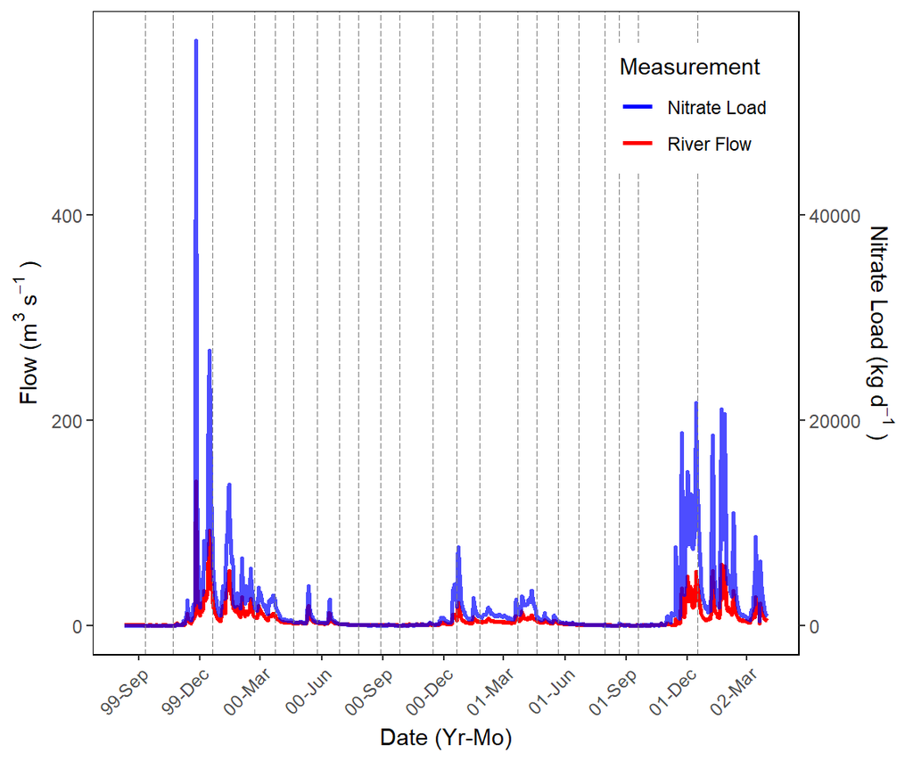

Here I created an additional figure to look at all the water column data. I omitted the samples that were taken at odd locations (7.1, 6b, 5b etc).

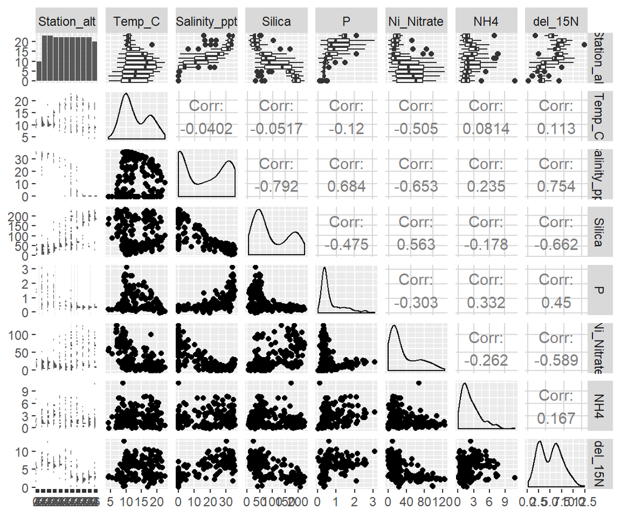

Next, I divided the data into seasons for comparison of water column characteristics. This allows us to boost sample numbers and generate estimates of variance.  
**Winter** = Dec, Jan, Feb  
**Spring** = March, Apr, May  
**Summer** = June, July, Aug  
**Fall** = Sept, Oct, Nov

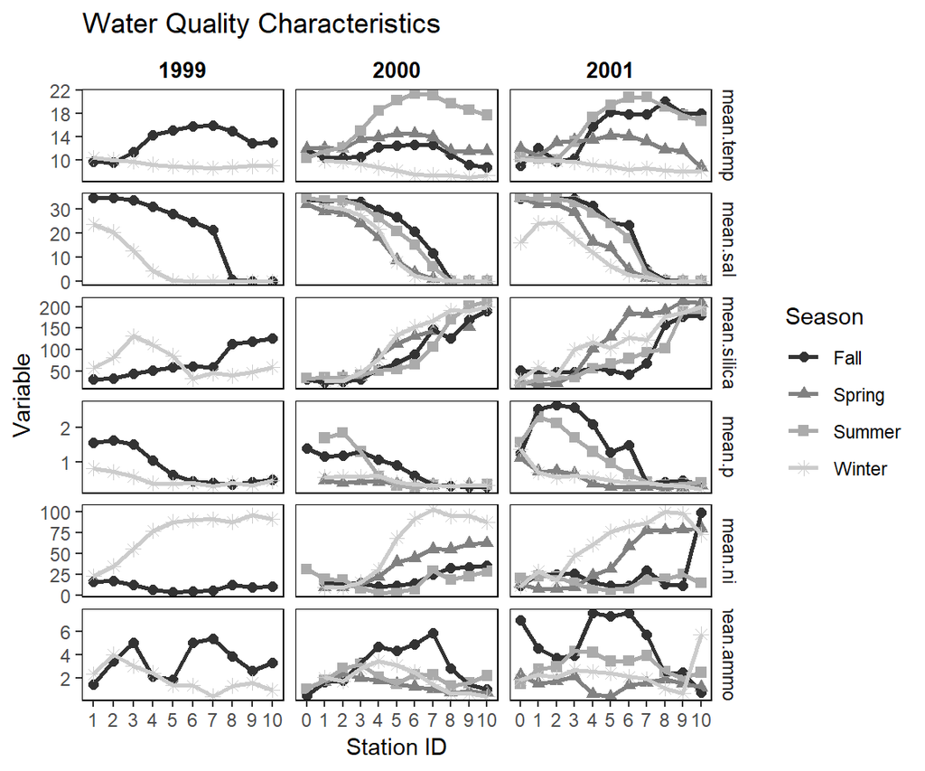

Separating out the individual variables for closer inspection and statistics.

### Salinity

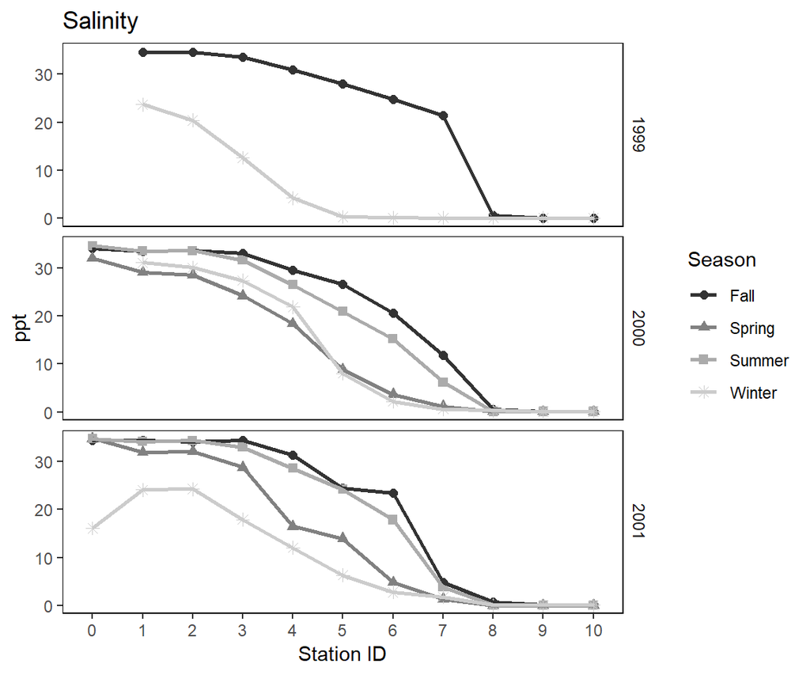

| Year | Season | SampleN | mean_var | sd_var | min_var | max_var |
| --- | --- | --- | --- | --- | --- | --- |
| 1999 | Fall | 20 | 20.869000 | 14.455934 | 0.070 | 34.9 |
| 1999 | Winter | 10 | 6.156000 | 9.282023 | 0.060 | 23.7 |
| 2000 | Fall | 21 | 20.058500 | 14.585164 | 0.080 | 34.7 |
| 2000 | Spring | 33 | 13.084242 | 13.068577 | 0.060 | 33.2 |
| 2000 | Summer | 33 | 18.400000 | 14.303482 | 0.060 | 35.5 |
| 2000 | Winter | 20 | 12.168500 | 13.496003 | 0.070 | 31.6 |
| 2001 | Fall | 11 | 20.263636 | 15.433293 | 0.100 | 34.5 |
| 2001 | Spring | 30 | 14.136533 | 13.666511 | 0.067 | 34.8 |
| 2001 | Summer | 31 | 19.303613 | 14.699063 | 0.060 | 35.4 |
| 2001 | Winter | 21 | 9.299524 | 11.547074 | 0.050 | 31.7 |

Conducting a simple ANCOVA of salinity by location, season and year. This was completed for all the water quality variables.

```r
sal.mod<-aov(sal$value~sal$Station_alt+sal$Season+sal$Year)
summary(sal.mod)
```

```
FALSE                  Df Sum Sq Mean Sq F value Pr(>F)
FALSE sal$Station_alt  10  36825    3683 153.880 <2e-16 ***
FALSE sal$Season        3   3387    1129  47.181 <2e-16 ***
FALSE sal$Year          2      3       2   0.072  0.931
FALSE Residuals       213   5097      24
FALSE ---
FALSE Signif. codes:  0 '***' 0.001 '**' 0.01 '*' 0.05 '.' 0.1 ' ' 1
FALSE 1 observation deleted due to missingness
```

```r
# different by station and Month but not year
```

### Temperature

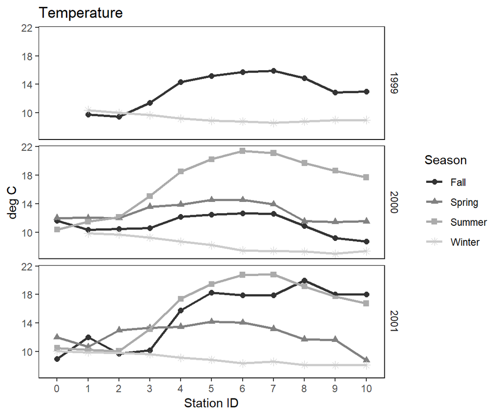

| Year | Season | SampleN | mean_var | sd_var | min_var | max_var |
| --- | --- | --- | --- | --- | --- | --- |
| 1999 | Fall | 20 | 13.255000 | 3.5701209 | 8.80 | 18.8 |
| 1999 | Winter | 10 | 9.240000 | 0.5929212 | 8.60 | 10.4 |
| 2000 | Fall | 21 | 11.033333 | 4.0161341 | 4.30 | 17.6 |
| 2000 | Spring | 33 | 12.820606 | 2.5381612 | 8.50 | 17.0 |
| 2000 | Summer | 33 | 16.939394 | 3.9503116 | 9.70 | 22.6 |
| 2000 | Winter | 20 | 8.220000 | 1.2176768 | 6.70 | 10.1 |
| 2001 | Fall | 11 | 15.163636 | 4.0888318 | 9.00 | 20.0 |
| 2001 | Spring | 30 | 12.522667 | 3.2932270 | 7.98 | 18.9 |
| 2001 | Summer | 31 | 16.161290 | 4.1624254 | 9.30 | 21.4 |
| 2001 | Winter | 21 | 8.928571 | 1.0359261 | 7.00 | 10.1 |

```r
temp.mod<-aov(temp$value~temp$Station_alt+sal$Season+temp$Year)
summary(temp.mod)
```

```
FALSE                   Df Sum Sq Mean Sq F value   Pr(>F)
FALSE temp$Station_alt  10  516.3    51.6   5.905 7.13e-08 ***
FALSE sal$Season         3 1831.6   610.5  69.829  < 2e-16 ***
FALSE temp$Year          2   13.6     6.8   0.776    0.461
FALSE Residuals        214 1871.0     8.7
FALSE ---
FALSE Signif. codes:  0 '***' 0.001 '**' 0.01 '*' 0.05 '.' 0.1 ' ' 1
```

```r
#not different by year
```

### Nitrate

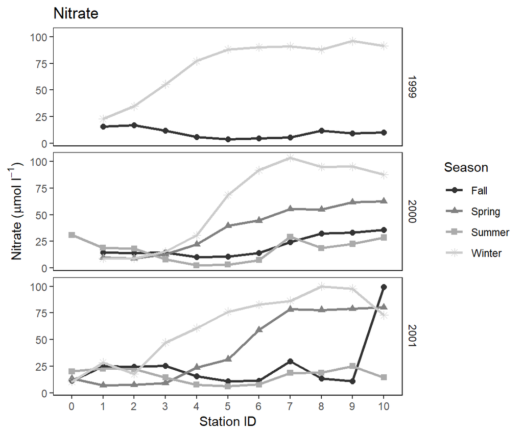

| Year | Season | SampleN | mean_var | sd_var | min_var | max_var |
| --- | --- | --- | --- | --- | --- | --- |
| 1999 | Fall | 20 | 9.47000 | 5.352530 | 1.1 | 21.3 |
| 1999 | Winter | 10 | 73.47000 | 26.368502 | 22.8 | 96.0 |
| 2000 | Fall | 21 | 20.35500 | 16.231466 | 5.7 | 61.0 |
| 2000 | Spring | 33 | 33.93667 | 24.639434 | 0.2 | 74.7 |
| 2000 | Summer | 33 | 16.44000 | 11.932644 | 0.1 | 48.4 |
| 2000 | Winter | 20 | 60.57000 | 42.072282 | 7.8 | 125.0 |
| 2001 | Fall | 11 | 25.15727 | 25.571787 | 10.8 | 99.3 |
| 2001 | Spring | 30 | 43.10667 | 33.558543 | 2.4 | 106.0 |
| 2001 | Summer | 31 | 16.10645 | 9.750587 | 0.1 | 39.9 |
| 2001 | Winter | 21 | 64.33619 | 36.542206 | 5.0 | 116.0 |

```r
nit.mod<-aov(Nitrate$value~Nitrate$Station_alt+Nitrate$Season+Nitrate$Year)
summary(nit.mod)
```

```
FALSE                      Df Sum Sq Mean Sq F value Pr(>F)
FALSE Nitrate$Station_alt  10  52790    5279  12.317 <2e-16 ***
FALSE Nitrate$Season        3  80863   26954  62.892 <2e-16 ***
FALSE Nitrate$Year          2    816     408   0.952  0.388
FALSE Residuals           207  88717     429
FALSE ---
FALSE Signif. codes:  0 '***' 0.001 '**' 0.01 '*' 0.05 '.' 0.1 ' ' 1
FALSE 7 observations deleted due to missingness
```

```r
# Not statistically different across years
```

### Phosphate

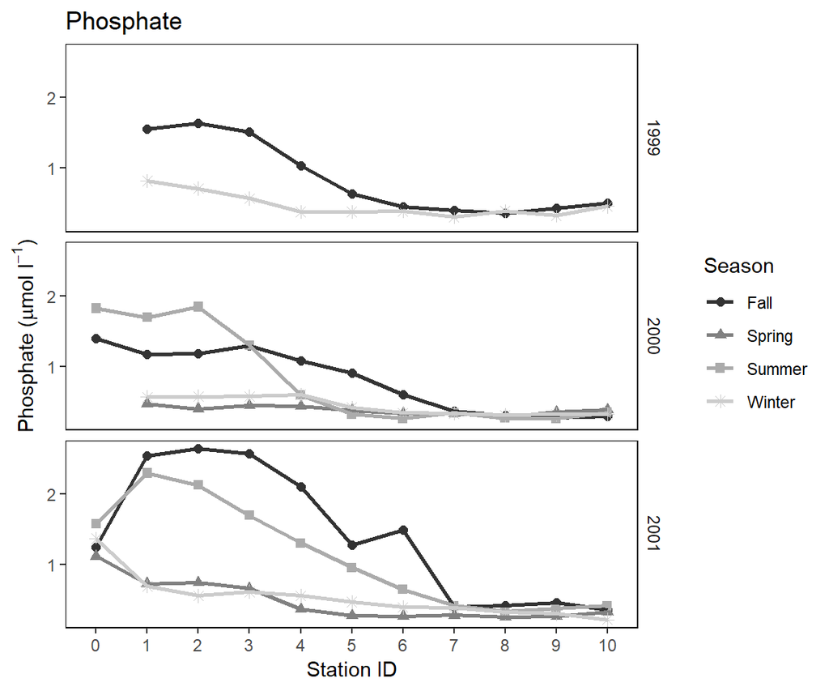

| Year | Season | SampleN | mean_var | sd_var | min_var | max_var |
| --- | --- | --- | --- | --- | --- | --- |
| 1999 | Fall | 20 | 0.8510000 | 0.5908682 | 0.21 | 2.18 |
| 1999 | Winter | 10 | 0.4740000 | 0.1713476 | 0.31 | 0.82 |
| 2000 | Fall | 21 | 0.7761905 | 0.5382980 | 0.22 | 1.86 |
| 2000 | Spring | 33 | 0.3866667 | 0.1470241 | 0.14 | 0.97 |
| 2000 | Summer | 33 | 0.8266667 | 0.7161118 | 0.03 | 2.54 |
| 2000 | Winter | 20 | 0.4350000 | 0.1252576 | 0.30 | 0.63 |
| 2001 | Fall | 11 | 1.4100000 | 0.9308920 | 0.36 | 2.64 |
| 2001 | Spring | 30 | 0.4446667 | 0.3541647 | 0.17 | 1.46 |
| 2001 | Summer | 31 | 1.1116129 | 0.7810510 | 0.18 | 3.10 |
| 2001 | Winter | 21 | 0.4966667 | 0.2561120 | 0.12 | 1.37 |

```r
Phos.mod<-aov(Phos$value~Phos$Station_alt+Phos$Season+Phos$Year)
summary(Phos.mod)
```

```
FALSE                   Df Sum Sq Mean Sq F value   Pr(>F)
FALSE Phos$Station_alt  10  31.26   3.126  20.169  < 2e-16 ***
FALSE Phos$Season        3  14.16   4.719  30.449 2.32e-16 ***
FALSE Phos$Year          2   2.29   1.146   7.393 0.000791 ***
FALSE Residuals        208  32.24   0.155
FALSE ---
FALSE Signif. codes:  0 '***' 0.001 '**' 0.01 '*' 0.05 '.' 0.1 ' ' 1
FALSE 6 observations deleted due to missingness
```

```r
#Statisically different across years. Appears to be driven by data from 2001
```

### Ammonium

[figure not shown]

| Year | Season | SampleN | mean_var | sd_var | min_var | max_var |
| --- | --- | --- | --- | --- | --- | --- |
| 1999 | Fall | 20 | 3.421500 | 1.7197683 | 0.96 | 5.85 |
| 1999 | Winter | 10 | 1.895000 | 1.0598663 | 0.45 | 4.01 |
| 2000 | Fall | 21 | 3.068095 | 2.0397466 | 0.13 | 7.32 |
| 2000 | Spring | 33 | 1.490333 | 1.3101105 | 0.27 | 5.99 |
| 2000 | Summer | 33 | 2.098667 | 1.4788759 | 0.05 | 5.44 |
| 2000 | Winter | 20 | 1.899500 | 1.3274054 | 0.30 | 4.87 |
| 2001 | Fall | 11 | 4.808182 | 2.3693958 | 0.79 | 7.57 |
| 2001 | Spring | 30 | 1.451000 | 0.7250938 | 0.18 | 3.36 |
| 2001 | Summer | 31 | 3.133226 | 1.8744499 | 0.32 | 7.62 |
| 2001 | Winter | 21 | 2.347619 | 2.1535248 | 0.59 | 10.80 |

```r
Ammon.mod<-aov(Ammon$value~Ammon$Station_alt+Ammon$Season+Ammon$Year)
summary(Ammon.mod)
```

```
FALSE                    Df Sum Sq Mean Sq F value   Pr(>F)
FALSE Ammon$Station_alt  10   53.5    5.35   2.120   0.0243 *
FALSE Ammon$Season        3  134.5   44.83  17.752 2.68e-10 ***
FALSE Ammon$Year          2   25.4   12.69   5.024   0.0074 **
FALSE Residuals         208  525.2    2.53
FALSE ---
FALSE Signif. codes:  0 '***' 0.001 '**' 0.01 '*' 0.05 '.' 0.1 ' ' 1
FALSE 6 observations deleted due to missingness
```

```r
#weak difference among stations. Significant difference among years.
```

### Silica

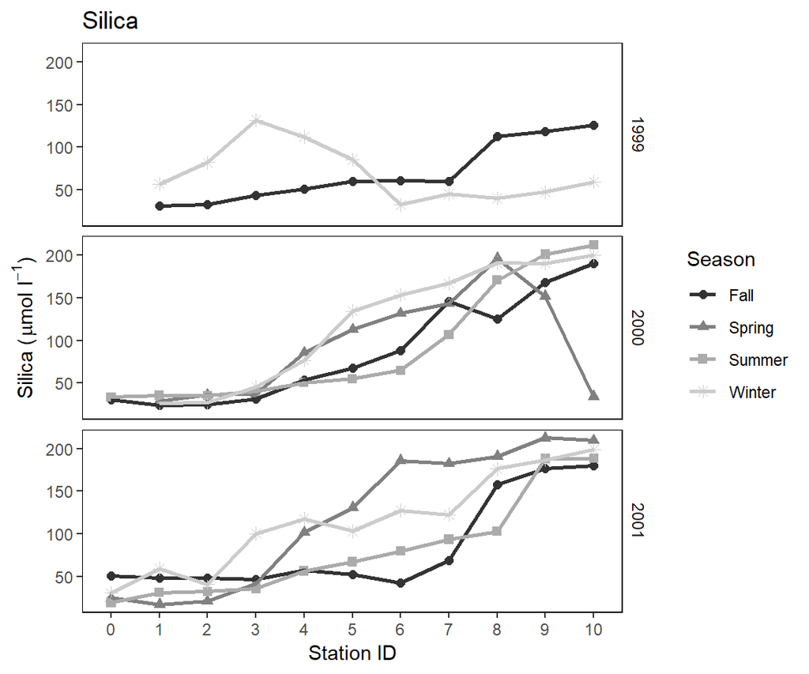

| Year | Season | SampleN | mean_var | sd_var | min_var | max_var |
| --- | --- | --- | --- | --- | --- | --- |
| 1999 | Fall | 20 | 69.23000 | 48.37736 | 14.80 | 181.30 |
| 1999 | Winter | 10 | 68.96200 | 32.87586 | 32.00 | 131.40 |
| 2000 | Fall | 21 | 88.92857 | 63.10485 | 10.40 | 198.00 |
| 2000 | Spring | 33 | 92.20552 | 76.52499 | 7.03 | 222.40 |
| 2000 | Summer | 33 | 91.30303 | 70.84008 | 10.10 | 216.90 |
| 2000 | Winter | 20 | 121.17700 | 73.33669 | 25.36 | 210.17 |
| 2001 | Fall | 11 | 84.28182 | 56.77654 | 42.20 | 180.00 |
| 2001 | Spring | 30 | 123.09000 | 78.65903 | 5.40 | 227.00 |
| 2001 | Summer | 31 | 79.74516 | 58.20910 | 9.10 | 200.00 |
| 2001 | Winter | 21 | 118.77333 | 71.95277 | 14.70 | 224.00 |

```r
sil.mod<-aov(Silica$value~Silica$Station_alt+Silica$Season+Silica$Year)
summary(sil.mod)
```

```
FALSE                     Df Sum Sq Mean Sq F value   Pr(>F)
FALSE Silica$Station_alt  10 603243   60324  32.647  < 2e-16 ***
FALSE Silica$Season        3  40589   13530   7.322 0.000108 ***
FALSE Silica$Year          2  24684   12342   6.679 0.001541 **
FALSE Residuals          210 388035    1848
FALSE ---
FALSE Signif. codes:  0 '***' 0.001 '**' 0.01 '*' 0.05 '.' 0.1 ' ' 1
FALSE 4 observations deleted due to missingness
```

```r
#Different among years


#pulling out the SI data only for the next section.
dat.temp2<-dat[,c(3,5,14:17,23)]
```

## Part 2: Suspended Sediment Characteristics

In this part of the analysis we look at isotope values for suspended sediments at each location sampled in the estuary. I conducted a couple of ANCOVA models to test for differences among **year**, **season** and **site** for each isotope. I have also created a matrix plot that looks at all the individual values for each **year** x **site** x **season** combination. In general, it is clear that the more samples become more enriched in del 13C and del 15N as we move down river. This might not the best way to present this but a good first stab.

```r
c.mod<-aov(dat.temp2$del_13C~dat.temp2$Station_alt+dat.temp2$Season+dat.temp2$Year)
summary(c.mod)
```

```
FALSE                        Df Sum Sq Mean Sq F value Pr(>F)
FALSE dat.temp2$Station_alt  10 1103.2  110.32  57.622 <2e-16 ***
FALSE dat.temp2$Season        3    6.9    2.31   1.205 0.3096
FALSE dat.temp2$Year          1    8.4    8.44   4.411 0.0373 *
FALSE Residuals             160  306.3    1.91
FALSE ---
FALSE Signif. codes:  0 '***' 0.001 '**' 0.01 '*' 0.05 '.' 0.1 ' ' 1
FALSE 55 observations deleted due to missingness
```

```r
n.mod<-aov(dat.temp2$del_15N~dat.temp2$Station_alt+dat.temp2$Season+dat.temp2$Year)
summary(n.mod)
```

```
FALSE                        Df Sum Sq Mean Sq F value Pr(>F)
FALSE dat.temp2$Station_alt  10  656.1   65.61  25.370 <2e-16 ***
FALSE dat.temp2$Season        3   25.8    8.60   3.326  0.021 *
FALSE dat.temp2$Year          1    0.8    0.83   0.321  0.572
FALSE Residuals             171  442.3    2.59
FALSE ---
FALSE Signif. codes:  0 '***' 0.001 '**' 0.01 '*' 0.05 '.' 0.1 ' ' 1
FALSE 44 observations deleted due to missingness
```

```r
#In general, marginal differences. I will pool all the values to increase sample size and remove temporal variation.
```

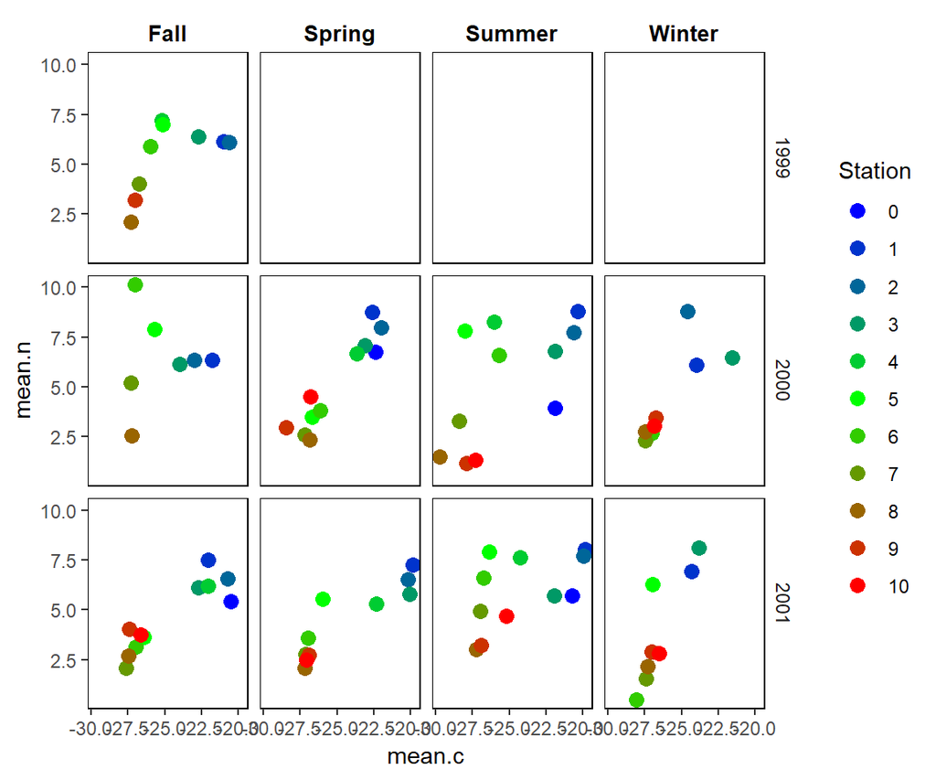

I combined the years and seasons together and plot by station and created a plot which included the zooplankton data. Open points are the zooplankton data.

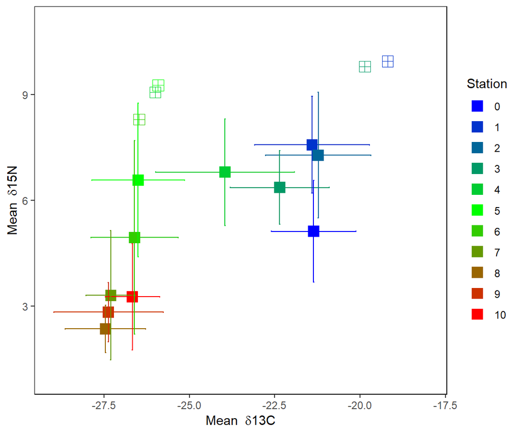

| Station_alt | mean.c | mean.n | sd.c | sd.n | mean.c.zoo | mean.n.zoo | sd.c.zoo | sd.n.zoo |
| --- | --- | --- | --- | --- | --- | --- | --- | --- |
| 0 | -21.36000 | 5.124000 | 1.2348927 | 1.4395385 | NaN | 12.160 | NA | NA |
| 1 | -21.40563 | 7.577500 | 1.6897809 | 1.3713035 | -19.19000 | 9.948 | 0.1044031 | 1.7498914 |
| 2 | -21.22588 | 7.281667 | 1.5468721 | 1.7788471 | -14.22143 | 9.650 | 15.8498375 | 0.2964793 |
| 3 | -22.35389 | 6.366111 | 1.4458547 | 1.0412613 | -19.86500 | 9.795 | 1.2232947 | 0.0636396 |
| 4 | -23.95786 | 6.801875 | 2.0375293 | 1.5108330 | -26.00667 | 9.066 | 1.1815385 | 0.6291900 |
| 5 | -26.50278 | 6.576250 | 1.3588178 | 2.1779926 | -25.92000 | 9.269 | 0.9258942 | 1.4288414 |
| 6 | -26.61056 | 4.950000 | 1.2802319 | 2.7421160 | -26.48000 | 8.298 | 1.6476347 | 0.8050901 |
| 7 | -27.30529 | 3.309000 | 0.7216831 | 1.8299350 | NaN | NaN | NA | NA |
| 8 | -27.46050 | 2.359000 | 1.1774928 | 0.6719485 | NaN | NaN | NA | NA |
| 9 | -27.37294 | 2.832105 | 1.6063537 | 0.8381765 | NaN | NaN | NA | NA |
| 10 | -26.67286 | 3.268667 | 0.7961584 | 1.5058831 | NaN | NaN | NA | NA |

To match this plot I conducted a cluster analysis to see if there are statistical groupings by the isotope values. This is multivariate analysis that takes into account both the C and N values together.

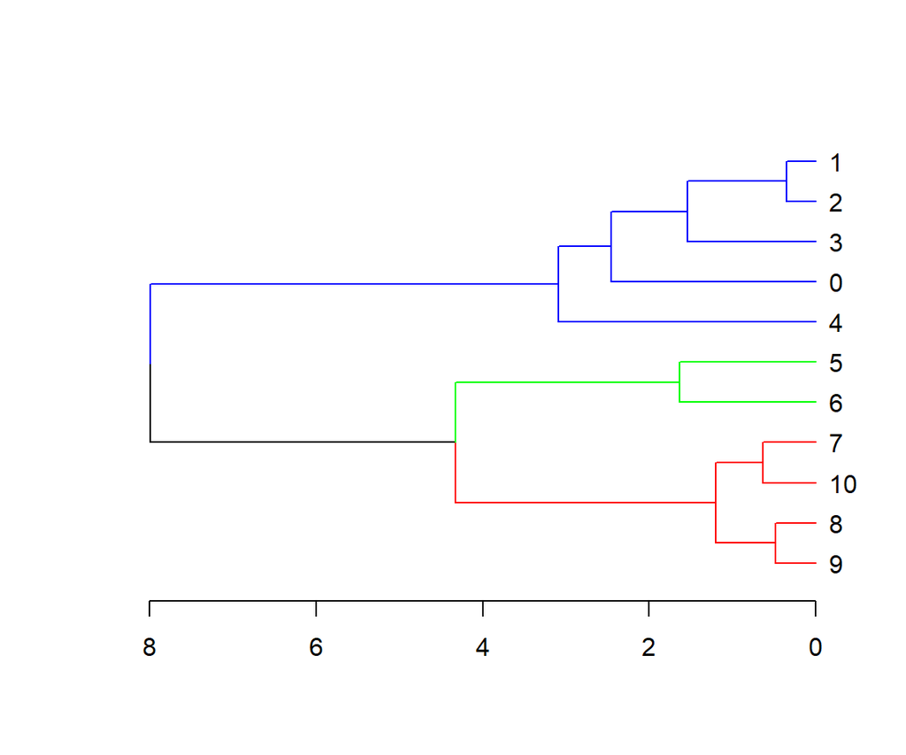

Based on the cluster, it looks like 3 strong groups along the estuarine gradient.  
**Lower estuary**: sites 0-4  
**Middle estuary**: sites 5-6  
**Upper estuary**: sites 7-10

### Additional Isotope visualizations

Next, I plotting the data a difference way, using barplots that looks at c and N separately. This might be the better way to present this data for this paper.

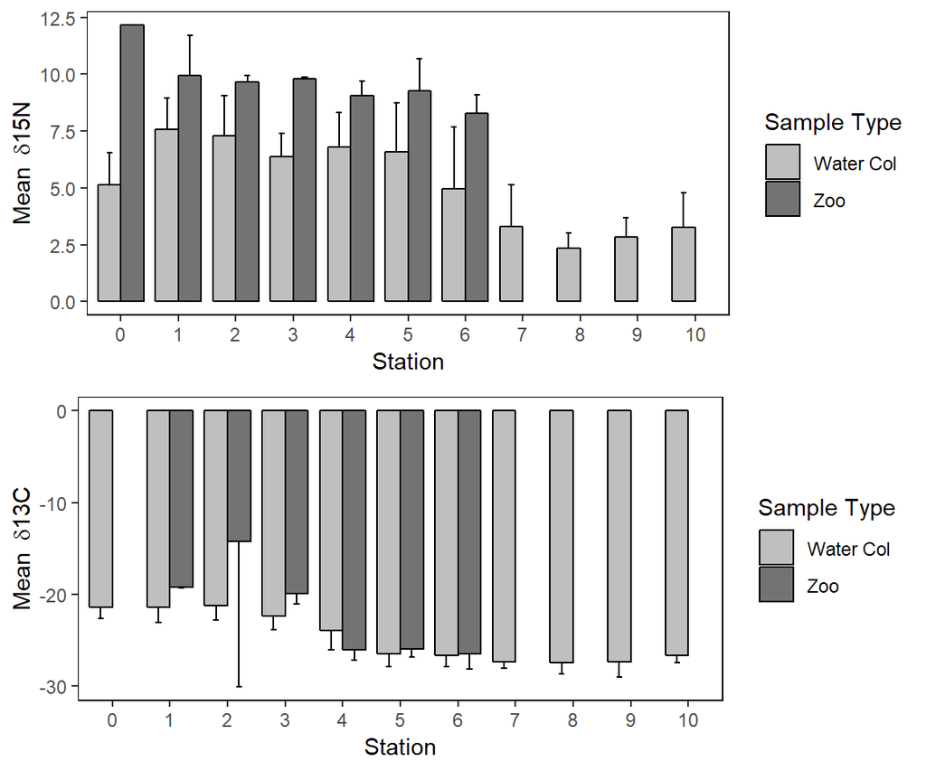

The **mean N15** enrichment of zooplankton relative to water col = 3.358371 +- 1.6895031

The **mean C13** enrichment of zooplankton relative to water col 1.7289152 +- 3.0589326

The difference in the isotope values at each location suggests that zooplankton are secondary consumers feeding on primary producers at each site.

**More to come soon!** What are the other data I needed to work up?